## Multivariate Stochastic Processes

# MULTIVARIATE STOCHASTIC PROCESSES

**DEFINITION**

A multivariate time series (x<sub>1</sub>, ... , x<sub>t</sub>, ... , x<sub>n</sub>) with x<sub>t</sub> = [ x<sub>1t</sub>, ... , x<sub>kt</sub>] is a finite realization of a multivariate stochastic process {X<sub>t</sub>}<sub>t∈[0,∞]</sub> where X<sub>t</sub> is a random vector defined on an appropriate probability space (Ω, Β<sub>R</sub>, P), with expected value equal to:  
E[x<sub>t</sub>]=μ<sub>t</sub>=[ μ<sub>1t</sub>, ... , μ<sub>kt</sub>]  
and autocovariance matrix equal to:  
E[x<sub>t</sub>, x<sub>t-j</sub>]= E[(x<sub>t</sub>-μ<sub>t</sub>) (x<sub>t-j</sub>-μ<sub>t-j</sub>)'] ----> for j ≠ 0  
E[x<sub>t</sub>, x<sub>t-j</sub>]= Var(x<sub>t</sub>-μ<sub>t</sub>) ----> for j = 0

**PROPERTIES**

Strong Stationarity:

A stochastic process is said to be strongly stationary if the distribution function of the process remains invariant to transformations.

Weak Stationarity:

A stochastic process is said to be weakly stationary if the expected value and autocovariance matrix do not vary as t varies.

Ergodicity:

A multivariate stochastic process is said to be ergodic if the mean of the transformed realizations for a function g(.) converges in probability to the expected value of the transformation applied to the process:  
n<sup>-1</sup>∑(g(x<sub>t</sub>))---<sub>P</sub>--->E[g(x<sub>t</sub>)]

Invertibility:

A stochastic process is said to be invertible if it is possible to express each element as a function of its past and a contemporary random component (WN):  
x<sub>t</sub>=f(x<sub>t-1</sub>,x<sub>t-2</sub>, ... ,u<sub>t</sub>)

**MULTIVARIATE WHITE NOISE**

A white-noise process is a weakly stationary process that has zero mean and is uncorrelated over time. A multivariate white noise is defined as the stochastic process {u<sub>t</sub> = [u<sub>1t</sub>,...,u<sub>kt</sub>]}<sub>t∈[0,∞]</sub> consisting of a sequence of k-dimensional random variables that are uncorrelated when referring to different time instants.  
In other words, the fact that a multivariate process is white noise excludes correlation between each element of the process and the past history of the entire process, but does not exclude that there may be correlation between contemporary elements.

# VARMA MODELS

A class of stationary stochastic processes, applicable to multiple phenomena considered jointly, is constituted by VARMA(p,q) models. These models represent a generalization of ARMA models used in the univariate context.  
A VARMA(p,q) model can be expressed in the form:  
X<sub>t</sub> = c + Φ<sub>1</sub>X<sub>t-1</sub> + ... + Φ<sub>p</sub>X<sub>t-p</sub> + u<sub>t</sub> + Θ<sub>1</sub>u<sub>t-1</sub> + ... + Θ<sub>q</sub>u<sub>t-q</sub>

- u<sub>t</sub> is the multivariate white noise process;
- c indicates a kx1 vector of deterministic constants;
- Φ<sub>j</sub> is a kxk matrix of autoregressive coefficients;
- Θ<sub>i</sub> are the coefficients for the moving average part.

VARMA models are rarely used in empirical applications for two reasons. First, the completeness of such a model creates significant problems regarding the precision of estimating the process parameters. Moreover, since in many circumstances the autoregressive part exhaustively explains the time series under examination (the moving average part has negligible relevance in the phenomenon's evolution, as it is due to transitory shocks that vanish over time), it is often preferable to neglect the moving average component, thus obtaining a particular case of the VARMA model, called VAR (vector autoregressive models).

# VAR MODELS

**DEFINITION**

We now consider a particular case of the VARMA(p,q) model where all coefficients of the moving average part Θ<sub>j</sub> are set equal to zero. The resulting model is called the VAR(p) model (endowed with the invertibility property) whose analytical expression is:  
(X<sub>t</sub> - μ) = Φ<sub>1</sub>(X<sub>t-1</sub> - μ) + ... + Φ<sub>p</sub>(X<sub>t-p</sub> - μ) + u<sub>t</sub>  
equivalently:  
(I<sub>k</sub> - Φ<sub>1</sub>L- ... - Φ<sub>p</sub>L<sup>p</sup>)(X<sub>t</sub> - μ) = u<sub>t</sub>  
or in compact form:  
Φ(L)(X<sub>t</sub> - μ) = u<sub>t</sub>  
where ut is a white noise. If we set p = 1 we obtain the VAR(1) model:  
(X<sub>t</sub> - μ) = Φ1(X<sub>t- 1</sub> - μ) + u<sub>t</sub>

**VAR IN FORMA COMPAGNA**

La rappresentazione in forma compagna permette di rappresentare ogni modello VAR(p) sotto forma di VAR(1). Partendo dal seguente modello:  
(X<sub>t</sub> - μ) = Φ1(X<sub>t- 1</sub> - μ) + u<sub>t</sub>  
Se si costriusce un sistema di equazione dove la prima è quella appena scritta e le altre sono:  
(X<sub>t-1</sub> - μ) = (X<sub>t-1</sub> - μ)  
...  
...  
...  
(X<sub>t-p+1</sub> - μ) = (X<sub>t-p+1</sub> - μ)  
si ottiene la forma compagna come:  
ε<sub>t</sub>=Fε<sub>t-1</sub>+v<sub>t</sub>

**STAZIONARIETA' DEL VAR**

Dato un processo VAR(1) esso si può definire stazionario in senso debole se gli autovalori λ<sub>i</sub> della matrice Φ<sub>1</sub> sono interni al cerchio unitario. Lo stesso ragionamento si può estendere ad un processo VAR(p) scritto in forma compagna come:  
ε<sub>t</sub>=Fε<sub>t-1</sub>+v<sub>t</sub>  
dove:

- ε<sub>t</sub> è un vettore (kp x 1) => [X<sub>t</sub> - μ, X<sub>t-1</sub> - μ, ... , X<sub>t-p+1</sub> - μ]
- F è una matrice (kp x kp) contenente nella prima riga il vettore delle Φ concatenato verticalmente con il prodotto di kronecker di una matrice identita di ordine k per una matrice identità di ordine p-1 concatenato con un vettore di zero di ampiezza p-1
- v<sub>t</sub> vt è un vettore (kp x 1), la cui prima componente è un vettore di k white noise.

Affinchè un processo X<sub>t</sub> possa essere definito stazionario occorre che tutti gli autovalori della matrice F siano interni al cerchio unitario.

**DAL VAR(∞) AL VAR(1)**

Se gli autovalori λ<sub>i</sub> della matrice Φ<sub>1</sub> sono interni al cerchio unitario (hanno modulo inferiore a 1) allora:

- Φ<sub>1</sub><sup>j</sup> -<sub><sub>j->∞</sub></sub>-> 0,
- ∑<sup>∞</sup><sub>j=0</sub> Φ<sub>1</sub><sup>j</sup> = (I<sub>k</sub> - Φ<sub>1</sub>)<sup>-1</sup> esiste finita;

inoltre il fatto che gli autovalori della matrice Φ<sub>1</sub> siano interni al cerchio unitario garantisce che Φ<sub>1</sub><sup>j</sup> -<sub><sub>j->∞</sub></sub>-> 0 e che ∑<sub>j=0</sub><sup>∞</sup> Φ<sub>1</sub><sup>j</sup> = (I<sub>k</sub> - Φ<sub>1</sub>)<sup>-1</sup>, il che implica l'assoluta sommabilità di questa stessa serie. Con queste due condizioni allora il processo VAR(1) è scrivibile come VMA(∞), e questo ne garantisce automaticamente la Stationarity.

**STIMA DI UN MODELLO VAR**

La procedura di individuazione del miglior modello VAR non è immediata, ma avviene attraverso il confronto di diversi modelli.  
La stima del modello avviene tramite un approccio di massima verosimiglianza e poichè le variabili si ipotizzano distribuite normalmente le stime di massima verosimiglianza ed i Minimi Quadrati Ordinari coincidono.  
Il primo passo consiste nello stabilire l'ordine p del modello. Questa scelta può avvenire attraverso un congruo bilanciamento fra numero di parametri e significatività della riduzione di verosimiglianza.  
In pratica ciò avviene mediante l'utilizzo delle funzioni di perdita, minimizzando una funzione crescente rispetto al numero di parametri e decrescente rispetto alla verosimiglianza.  
cosideriamo un modello VAR(p):  
(X<sub>t</sub> - μ) = Φ<sub>1</sub>(X<sub>t-1</sub> - μ) + ... + Φ<sub>p</sub>(X<sub>t-p</sub> - μ) + u<sub>t</sub>  
dove u<sub>t</sub> ∼ WN(0 , Σ)  
Con il metodo ML vogliamo ottenere delle stime per Φ e Σ, tuttavia essendo che le variabili sono correlate non possiamo scrivere la funzione di verosimiglianza come prodotto delle marginali quindi risulta più comodo considerare la funzione di verosimiglianza condizionata:  
L<sup>C</sup>(Φ<sub>1</sub>, ... , Φ<sub>p</sub> ; Σ) = ƒ<sub><sub><sub>X<sub>t+n</sub>, ... ,X<sub>t+1</sub></sub>|<sub>X<sub>t</sub>=x<sub>t</sub>, ... , X<sub>t-p+1</sub>=x<sub>t-p+1</sub></sub></sub></sub>(X<sub>t+n</sub>, ... , X<sub>t+1</sub>)=

= ∏<sup>n</sup><sub>i=1</sub> ƒ<sub><sub><sub>X<sub>t+i</sub></sub>|<sub>x<sub>t</sub>, ... , x<sub>t-p+1</sub></sub></sub></sub>(X<sub>t+i</sub>)

Resta da individuare la ƒ<sub><sub><sub>X<sub>t+i</sub></sub>|<sub>x<sub>t</sub>, ... , x<sub>t-p+1</sub></sub></sub></sub>(X<sub>t+i</sub>), analizzando il processo X<sub>t+i</sub> (che è un VAR(p)) e sapendo che u<sub>t</sub> ∼ WN ∼ N(0 , Σ) possiamo arrivare alla conclusione che:  
X<sub>t+i</sub>|x<sub>t</sub>, ... , x<sub>t-p+1</sub> ∼ N(Π<sup>T</sup> Z<sub>t+i</sub> , Σ)  
dove: X<sub>t+i</sub> = c + Φ<sub>1</sub>X<sub>t+i</sub> + ... + Φ<sub>p+i</sub>X<sub>t-p+1</sub>  
e quindi:  
Π<sup>T</sup> = [c , Φ<sub>1</sub> , ... + Φ<sub>p+i</sub>]  
Z<sub>t+i</sub> = [1 , X<sub>t+i</sub> , ... , X<sub>t-p+1</sub>]<sup>T</sup>  
Sapendo che la distribuzione condizionata di X<sub>t+i</sub>|(al suo passato) ∼ N(Π<sup>T</sup> Z<sub>t+i</sub> , Σ) possiamo procedere con la stima ML:  
(Π<sup>ML</sup>)<sup><sup>T</sup></sup> = [∑<sup>n</sup><sub>i=1</sub> (X<sub>t+i</sub> Z<sup>T</sup><sub>t+i</sub>)][∑<sup>n</sup><sub>i=1</sub> (X<sub>t+i</sub> Z<sup>T</sup><sub>t+i</sub>)]<sup>-1</sup>  
Σ<sup>ML</sup> = n<sup>-1</sup> ∑<sup>n</sup><sub>i=1</sub> {[X<sub>t+i</sub> - (Π<sup>ML</sup>)<sup><sup>T</sup></sup>Z<sub>t+i</sub>][X<sub>t+i</sub> - (Π<sup>ML</sup>)<sup><sup>T</sup></sup>Z<sub>t+i</sub>]<sup>T</sup>}

**TEST DI ESCLUSIONE RICORSIVA DEI RITARDI**

Il test ad esclusione ricorsiva dei ritardi si basa sul rapporto di verosimiglianza e ha come obbiettivo quello di individuare l'ordine p di ritardi migliore per il modello VAR(p):  
H<sub>0</sub>: p = p<sub>0</sub>  
H<sub>1</sub>: p = p<sub>1</sub> (t.c. p<sub>1</sub> > p<sub>0</sub>)  
Si considera:  
λ(x) = <sup>L<sup>C</sup>(Π<sub>0</sub><sup>ML</sup> , Σ<sub>0</sub><sup>ML</sup>)</sup> / <sub>L<sup>C</sup>(Π<sub>1</sub><sup>ML</sup> , Σ<sub>1</sub><sup>ML</sup>)</sub>  
Secondo il teorema di wald sappiamo che:  
W(x) = -2log(λ(x)) = -2[l<sup>C</sup>(Π<sub>0</sub><sup>ML</sup> , Σ<sub>0</sub><sup>ML</sup>) - l<sup>C</sup>(Π<sub>1</sub><sup>ML</sup> , Σ<sub>1</sub><sup>ML</sup>)]  
dove: W(x) ∼ χ<sup>2</sup><sub><sub>p<sub>1</sub>-p<sub>0</sub></sub></sub>  
Questo vuol dire che la zona di rifiuto sarà:  
R={x tc W(x)>q<sub>(α, χ<sup>2</sup><sub><sub>p<sub>1</sub>-p<sub>0</sub></sub></sub> )</sub> }  
Dove q<sub>(α, χ<sup>2</sup><sub><sub>p<sub>1</sub>-p<sub>0</sub></sub></sub></sub> ) è il quantile di ordine α di una χ<sup>2</sup><sub><sub>p<sub>1</sub>-p<sub>0</sub></sub></sub>.  
Un altro modo per individuare l'ordine p dei ritardi consiste nell'adottare metodi che minimizzano funzioni crescenti nei parametri e decrescenti rispetto alla verosimiglianza, queste funzioni sono dette funzioni di perdita. Le principali utilizzate in questo ambito sono le funzioni di Akaike, di Hannan e Quinn e di Schwarz:  
AIC(p) = -2 n<sup>-1</sup> l(θ , p) + 2 n<sup>-1</sup> p k<sup>2</sup> ->p più elevato  
HQ(p) = -2 n<sup>-1</sup> l(θ , p) + 2 n<sup>-1</sup> log(n<sup>-1</sup> log(n)) p k<sup>2</sup>  
AIC(p) = -2 n<sup>-1</sup> l(θ , p) + 2 n<sup>-1</sup> log(n) p k<sup>2</sup> ->p più basso  
Un terzo metodo, anche se non molto pratico, può essere quello di valutare piu modelli in base alla correlazioni con i residui tenendo conto che un buon modello deve avere circa il 95% dei residui non correlati.

```r
#### Modelli VAR
    data(Canada) #dati macroeconomici sul Canada
    summary(Canada)
```

```
##        e              prod             rw              U
##  Min.   :928.6   Min.   :401.3   Min.   :386.1   Min.   : 6.700
##  1st Qu.:935.4   1st Qu.:404.8   1st Qu.:423.9   1st Qu.: 7.782
##  Median :946.0   Median :406.5   Median :444.4   Median : 9.450
##  Mean   :944.3   Mean   :407.8   Mean   :440.8   Mean   : 9.321
##  3rd Qu.:950.0   3rd Qu.:410.7   3rd Qu.:461.1   3rd Qu.:10.607
##  Max.   :961.8   Max.   :418.0   Max.   :470.0   Max.   :12.770
```

```r
    #Scelta dell'ordine dei ritardi
    #Selezione dell'ordine dei ritardi con 4 criteri
    VARselect(Canada, lag.max = 12, type="const")
```

```
## $selection
## AIC(n)  HQ(n)  SC(n) FPE(n)
##      3      1      1      3
##
## $criteria
##                   1            2            3            4            5
## AIC(n) -6.655129808 -6.814854295 -6.868744361 -6.666586167 -6.460700426
## HQ(n)  -6.403366607 -6.361680533 -6.214160038 -5.810591283 -5.403294982
## SC(n)  -6.022722553 -5.676521235 -5.224485498 -4.516401499 -3.804589954
## FPE(n)  0.001288555  0.001103138  0.001056564  0.001319817  0.001676682
##                   6            7            8            9          10
## AIC(n) -6.363384957 -6.292604661 -6.279055217 -6.201794055 -6.17085150
## HQ(n)  -5.104568952 -4.832378095 -4.617418090 -4.338746367 -4.10639325
## SC(n)  -3.201348681 -2.624642580 -2.105167332 -1.521980366 -0.98511201
## FPE(n)  0.001944191  0.002244786  0.002518411  0.003123173  0.00387657
##                  11           12
## AIC(n) -6.229490861 -6.447761913
## HQ(n)  -3.963622052 -3.980482542
## SC(n)  -0.537825564 -0.250170811
## FPE(n)  0.004681472  0.005242163
```

```r
     #Stima del modello Var con 3 ritardi
    m1<-VAR(Canada, p = 3, type = "const")

    summary(m1)
```

```
##
## VAR Estimation Results:
## =========================
## Endogenous variables: e, prod, rw, U
## Deterministic variables: const
## Sample size: 81
## Log Likelihood: -150.609
## Roots of the characteristic polynomial:
## 1.004 0.9283 0.9283 0.7437 0.7437 0.6043 0.6043 0.5355 0.5355 0.2258 0.2258 0.1607
## Call:
## VAR(y = Canada, p = 3, type = "const")
##
##
## Estimation results for equation e:
## ==================================
## e = e.l1 + prod.l1 + rw.l1 + U.l1 + e.l2 + prod.l2 + rw.l2 + U.l2 + e.l3 + prod.l3 + rw.l3 + U.l3 + const
##
##           Estimate Std. Error t value Pr(>|t|)
## e.l1       1.75274    0.15082  11.622  < 2e-16 ***
## prod.l1    0.16962    0.06228   2.723 0.008204 **
## rw.l1     -0.08260    0.05277  -1.565 0.122180
## U.l1       0.09952    0.19747   0.504 0.615915
## e.l2      -1.18385    0.23517  -5.034 3.75e-06 ***
## prod.l2   -0.10574    0.09425  -1.122 0.265858
## rw.l2     -0.02439    0.06957  -0.351 0.727032
## U.l2      -0.05077    0.24534  -0.207 0.836667
## e.l3       0.58725    0.16431   3.574 0.000652 ***
## prod.l3    0.01054    0.06384   0.165 0.869371
## rw.l3      0.03824    0.05365   0.713 0.478450
## U.l3       0.34139    0.20530   1.663 0.100938
## const   -150.68737   61.00889  -2.470 0.016029 *
## ---
## Signif. codes:  0 '***' 0.001 '**' 0.01 '*' 0.05 '.' 0.1 ' ' 1
##
##
## Residual standard error: 0.3399 on 68 degrees of freedom
## Multiple R-Squared: 0.9988,	Adjusted R-squared: 0.9985
## F-statistic:  4554 on 12 and 68 DF,  p-value: < 2.2e-16
##
##
```

[output cut: 80 more lines]

```
##
##
## Covariance matrix of residuals:
##             e     prod       rw        U
## e     0.11550 -0.03161 -0.03681 -0.07034
## prod -0.03161  0.42449  0.05589  0.01494
## rw   -0.03681  0.05589  0.57780  0.03660
## U    -0.07034  0.01494  0.03660  0.07945
##
## Correlation matrix of residuals:
##            e     prod      rw        U
## e     1.0000 -0.14276 -0.1425 -0.73426
## prod -0.1428  1.00000  0.1129  0.08136
## rw   -0.1425  0.11286  1.0000  0.17084
## U    -0.7343  0.08136  0.1708  1.00000
```

```r
    roots(m1) #radici del modello VAR
```

```
##  [1] 1.0038607 0.9282722 0.9282722 0.7436701 0.7436701 0.6043160 0.6043160
##  [8] 0.5354599 0.5354599 0.2257507 0.2257507 0.1606576
```

```r
    roots(m1,modulus = F) #radici del modello VAR come numeri complessi
```

```
##  [1]  1.0038607+0.0000000i  0.9264902+0.0574900i  0.9264902-0.0574900i
##  [4]  0.7048399+0.2371623i  0.7048399-0.2371623i  0.1092774+0.5943536i
##  [7]  0.1092774-0.5943536i -0.1181711+0.5222575i -0.1181711-0.5222575i
## [10]  0.1907349+0.1207625i  0.1907349-0.1207625i -0.1606576+0.0000000i
```

```r
    residuals(m1)
```

```
##               e        prod           rw           U
## 1   0.396121511  0.11840048  0.659939985 -0.43738364
## 2   0.249065788  0.71742949  0.431450548  0.15319901
## 3   0.177175520  0.06623809  1.384352350 -0.09961548
## 4  -0.096351638 -0.93100815 -1.237251416  0.05339949
## 5  -0.034436534  0.06846126  2.075215983  0.12308452
## 6  -0.447350640  0.49219100  0.115836902 -0.14146982
## 7  -0.609808396 -0.40496047  0.293517252  0.53160459
## 8  -0.615737798  1.16668022 -0.643492743  0.61839378
## 9   0.006032917  0.39733305  0.120832350 -0.04799867
## 10  0.167250285  0.65813337 -1.438020699 -0.40110084
## 11 -0.067311190 -0.72145313  0.394209375  0.14627210
## 12  0.039902231 -0.74312679 -0.284892821  0.16797709
## 13 -0.575903232  0.31992989  1.147899743  0.16852248
## 14 -0.177616108  0.48710456  0.128979113  0.17964754
```

[output cut: 67 more lines]

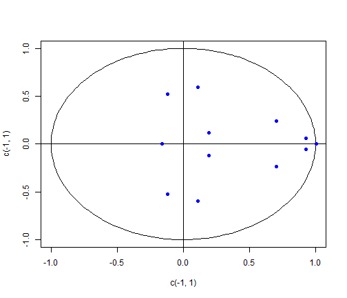

```r
    #rappresentazione delle radici sul cerchio unitario
    plot(c(-1, 1), c(-1, 1), type = "n")
    radius <- 1
    theta <- seq(0, 2 * pi, length = 200)
    lines(x = radius * cos(theta), y = radius * sin(theta))
    abline(h=0); abline(v=0)
    points(roots(m1,modulus = F),col=4,pch=16)
```

**GLI UTILIZZI DEL VAR**

*Previsione*  
Il migliore previsore è quello ce minimizza l'erroe quadratico medio (MSE), ovvero il valore atteso della v.c. X<sub>t+1</sub> condizionata all'informazione posseduta al tempo t. Quindi la previsione al tempo t+1 è data da:  
stima -> x<sub><sub>t+1</sub>|<sub>ℑ<sub>t</sub></sub></sub> ≡ E[X<sub>t+1</sub>|ℑ<sub>t</sub>]  
*Risposta agli impulsi*  
La funzione di risposta agli impulsi è utile per registrare le reazioni del sistema a shock improvvisi rispetto a ciascuna delle k variabili considerte nel processo. La funzione a risposta di impulso serve inoltre a valutare le caratteristiche di persistenza i un dato processo  
*Scomposizione della varianza di previsione*  
L'errore si compie nel prevedere l'evoluzione del VAR, h periodi avanti è data dall'espressione:  
MSE[E[X<sub>(t+h)</sub>|ℑ<sub>t</sub>]] = Σ + Θ<sub>1</sub> Σ Θ'<sub>1</sub> + ... + Θ<sub>h-1</sub> Σ Θ'<sub>h-1</sub>  
dove Σ = E[u<sub>t</sub> u'<sub>t</sub>]  
*Analysis di casualità di Grenger*  
La correlazione fra due variabili implica l'esistenza di un legame ma non sappiamo il tipo di rapporto di causa-effetto che le lega.  
Granger ha procao a studiare questo rapporto, in particolare se X<sub>t</sub> e Y<sub>t</sub> sono due serie storiche si afferma che Y<sub>t</sub> non Granger-causa X<sub>t</sub> se la previsione X<sub>t+s</sub> sulla base dell'informazione di X al tempo t è non peggiore della stessa previsione ottenuta però sulla base dell'informazione su x<sub>t</sub> e Y<sub>t</sub>

```r
#### Utilizzi del VAR

    #Previsione
    library(vars)
    data(Canada)
    summary(Canada)
```

```
##        e              prod             rw              U
##  Min.   :928.6   Min.   :401.3   Min.   :386.1   Min.   : 6.700
##  1st Qu.:935.4   1st Qu.:404.8   1st Qu.:423.9   1st Qu.: 7.782
##  Median :946.0   Median :406.5   Median :444.4   Median : 9.450
##  Mean   :944.3   Mean   :407.8   Mean   :440.8   Mean   : 9.321
##  3rd Qu.:950.0   3rd Qu.:410.7   3rd Qu.:461.1   3rd Qu.:10.607
##  Max.   :961.8   Max.   :418.0   Max.   :470.0   Max.   :12.770
```

```r
    m1<-VAR(Canada, p = 3, type = "const")
    predict(m1, n.ahead = 5, ci = 0.95)
```

```
## $e
##          fcst    lower    upper        CI
## [1,] 962.8355 962.1694 963.5016 0.6661063
## [2,] 964.1396 962.8205 965.4587 1.3190726
## [3,] 965.5223 963.6664 967.3782 1.8559305
## [4,] 966.8774 964.6137 969.1411 2.2636929
## [5,] 968.1325 965.5151 970.7499 2.6173821
##
## $prod
##          fcst    lower    upper       CI
## [1,] 417.4415 416.1645 418.7185 1.276970
## [2,] 418.0955 416.1377 420.0533 1.957804
## [3,] 418.8073 416.3501 421.2645 2.457200
## [4,] 419.3108 416.4527 422.1689 2.858117
## [5,] 419.6458 416.4004 422.8911 3.245365
##
## $rw
##          fcst    lower    upper       CI
## [1,] 470.0419 468.5521 471.5318 1.489829
## [2,] 470.8222 468.7613 472.8832 2.060919
## [3,] 471.2779 468.9004 473.6554 2.377508
## [4,] 471.7219 469.0327 474.4110 2.689163
## [5,] 472.3777 469.3794 475.3759 2.998213
##
## $U
##          fcst    lower    upper        CI
## [1,] 6.484233 5.931795 7.036672 0.5524385
## [2,] 5.831105 4.922149 6.740061 0.9089557
## [3,] 5.166632 3.918600 6.414664 1.2480320
## [4,] 4.576521 3.065484 6.087559 1.5110372
## [5,] 4.051549 2.350973 5.752125 1.7005762
```

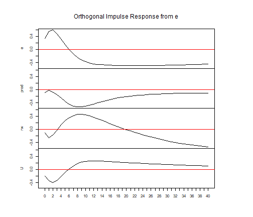

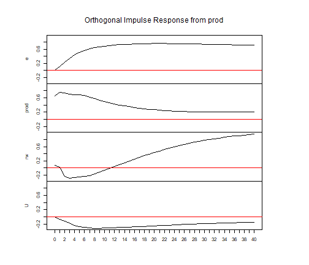

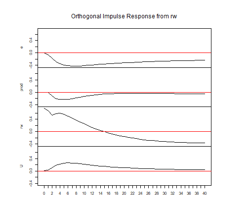

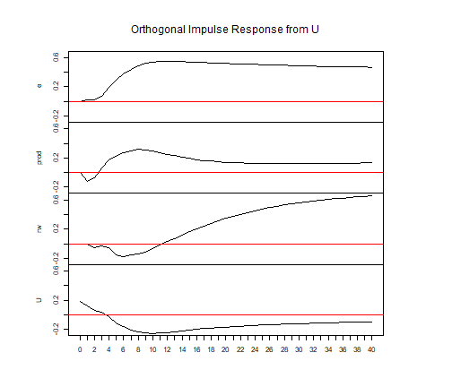

```r
    #Risposta agli impulsi (Analysis dinamica)
    imp<-irf(m1, impulse = c("e","prod", "rw", "U"),
             response = c("e","prod", "rw", "U"),
             boot = FALSE,n.ahead = 40)
    plot(imp)
```

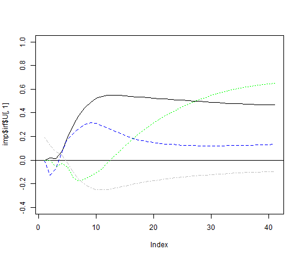

```r
    plot(imp$irf$U[,1],type="l",ylim=c(-0.4,1))
    abline(h=0)
    lines(imp$irf$U[,2],lty=2,col="blue")
    lines(imp$irf$U[,3],lty=3,col="green")
    lines(imp$irf$U[,4],lty=4,col="gray")
```

```r
    #Scomposizione della varianza di previsione
    fevd(m1, n.ahead = 5)
```

```
## $e
##              e       prod          rw            U
## [1,] 1.0000000 0.00000000 0.000000000 0.0000000000
## [2,] 0.9679295 0.02335231 0.007926938 0.0007912516
## [3,] 0.8901016 0.07017553 0.039079270 0.0006436471
## [4,] 0.7767949 0.13515474 0.083448990 0.0046014017
## [5,] 0.6413324 0.20621412 0.128869199 0.0235842576
##
## $prod
##                e      prod           rw          U
## [1,] 0.020380831 0.9796192 0.000000e+00 0.00000000
## [2,] 0.009233159 0.9750352 2.297056e-05 0.01570867
## [3,] 0.010597113 0.9666723 9.394910e-03 0.01333570
## [4,] 0.019496778 0.9415248 2.689223e-02 0.01208623
## [5,] 0.037266067 0.9025632 3.977396e-02 0.02039678
##
## $rw
##               e        prod        rw            U
## [1,] 0.02029883 0.008738054 0.9709631 0.000000e+00
## [2,] 0.06827676 0.005031703 0.9266915 2.063692e-08
## [3,] 0.07114374 0.037957529 0.8885843 2.314384e-03
## [4,] 0.05593555 0.072967669 0.8689615 2.135299e-03
## [5,] 0.05387566 0.088640298 0.8542818 3.202191e-03
##
## $U
##              e        prod          rw          U
## [1,] 0.5391325 0.000562155 0.004824606 0.45548072
## [2,] 0.7333695 0.020725917 0.004418956 0.24148560
## [3,] 0.7815156 0.045194065 0.033812485 0.13947783
## [4,] 0.7327095 0.084688479 0.084300593 0.09830144
## [5,] 0.6426027 0.143944586 0.135094921 0.07835783
```

```r
    #Esempio su Analysis di causalità di Granger
    data(ChickEgg)
    summary(ChickEgg)
```

```
##     chicken            egg
##  Min.   :364584   Min.   :3081
##  1st Qu.:387658   1st Qu.:5008
##  Median :403819   Median :5380
##  Mean   :419504   Mean   :4986
##  3rd Qu.:433773   3rd Qu.:5530
##  Max.   :582197   Max.   :5836
```

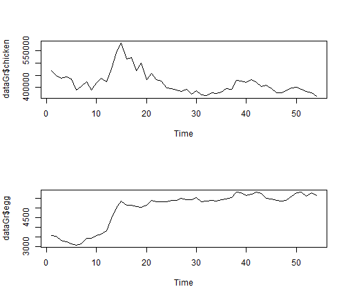

```r
    dataGr<-as.data.frame(ChickEgg)
    par(mfrow=c(2,1))
    plot.ts(dataGr$chicken)
    plot.ts(dataGr$egg)
```

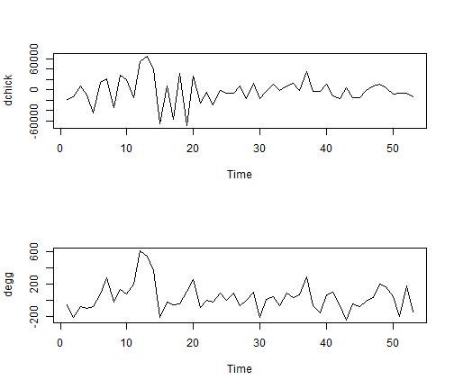

```r
    dchick <- diff(dataGr$chicken)
    degg <- diff(dataGr$egg)
    plot.ts(dchick)
    plot.ts(degg)
```

```r
     #p-valore sotto 0.05 quindi c'e' differenza fra i due modelli
    grangertest(dchick ~ degg, order=4)
```

```
## Granger causality test
##
## Model 1: dchick ~ Lags(dchick, 1:4) + Lags(degg, 1:4)
## Model 2: dchick ~ Lags(dchick, 1:4)
##   Res.Df Df      F   Pr(>F)
## 1     40
## 2     44 -4 4.1762 0.006414 **
## ---
## Signif. codes:  0 '***' 0.001 '**' 0.01 '*' 0.05 '.' 0.1 ' ' 1
```

```r
     #p-valore sopra 0.05 nessuna differenza fra i due modelli
    grangertest(degg ~ dchick, order=4)
```

```
## Granger causality test
##
## Model 1: degg ~ Lags(degg, 1:4) + Lags(dchick, 1:4)
## Model 2: degg ~ Lags(degg, 1:4)
##   Res.Df Df      F Pr(>F)
## 1     40
## 2     44 -4 0.2817 0.8881
```

**GLI UTILIZZI DEL VAR**

Una volta otttenuta la stima dei coefficienti del VAR(p), ci si può trovare in una situazione di non Stationarity se qualche autovalore λ<sub>i</sub> della matrice F (matrice dei coefficienti del VAR(p) in forma compagna) si trova fuori dal cerchio dell'unità o sul cerchio unitario.  
La situazione riulta più incerta se, invece, qualche autovalore si trova molto in prossimità ad 1, in questo caso dovrei testare la Stationarity con un test di non Stationarity come ad esempio quello di Dickey Fuller, in quanto in caso di non Stationarity cedrebbero tutti i risultati circa la consistenza degli stimatori, in caso di non Stationarity può essere utilizzata la regressione.  
Un problema che si pone nel caso si dicida di passare alla regressione ma ci vengano dei coefficienti uguali a 0 (il che implicherebbe la Stationarity) risulta essere quello della correlazione dei residui.  
Occorre distinguere due casi:

- una correlazione si dice spuria (o nonsense correlation) se lega due fenomeni che non hanno alcun nesso causale, che non hanno nulla in comune;

```
Y Spese per la difesa USA, 1971-1990

X Popolazione in Sud Africa, 1971-1990

Y = -368.99 + 0.0179 X
(-11.34) (16.75)

R^2 = 0.940, D/W = 0.4069, F = 280.69

Corr = .9694
```

- si dice invece indiretta quando due variabili X e Y sono correlate perchè in realtà correlate entrambe a una variabile Z.

Un esempio classico è quello che lega la variabile X=numero di vittime in un incendio alla variabile Y=numero pompieri impiegati per spegnerlo. Si riscontra facilmente una correlazione positiva: più pompieri, più vittime; sarebbe pertanto "logico", ma completamente assurdo, pensare che impiegando meno pompieri si avrebbero meno vittime. Ovviamente X e Y dipendono dalla terza variabile Z=dimensione dell'incendio.

Come soluzione a questi problemi si può differenziare cosi da togliere il trend stocastico quando due variabili risultano correlate.